# CLEAR-3 ICA analysis pipeline

This is a streamlined version of the analysis done in the manuscript, assembled from a variety of original analysis files. These files still reside in this repository for archival purposes (which means, unfortunately, that we have a certain degree of code duplication).

The pipeline is divided into three parts: Preprocessing, independent component analysis (ICA), and linear mixed-effects modelling. The meat of the preprocessing code has been delegated to R source files, which can be found in the `src` folder. The ICA and modelling code, on the other hand, is more verbose to allow easier exposition of, e.g., model structure.

```r
knitr::opts_chunk$set(cache = TRUE, message = FALSE)
local <- TRUE

wd <- ""

if (!local) {
  # Cluster environment
  wd <- "~/Documents/Autocorrelation"
  # Base directory for the data set we will create
  dat_dir <- "/project_cephfs/3022017.02/projects/lorkno/data"
} else {
  wd <- "/Volumes/home/preclineu/lorkno/Documents/Autocorrelation"
  # Base directory for the data set we will create
  dat_dir <- "~/HPC_project/data"
}

# For some reason this sets the pwd only for the current scope, which means it
# does not affect anything outside an if block if you set it there.
# So that's why it's here instead of above.
setwd(wd)

src_dir <- "src"
source(file.path(src_dir, "load_dependencies.R"))

man_img_dir <- "~/Documents/Writing/Papers/Paper 1/images"
```

# Preprocessing

These functions repair potential file errors, move files into a BIDS-like structure, and then perform filtering and aggregation where necessary.

```r
source(file.path(src_dir, "preproc_all.R"))

dir.create(dat_dir, showWarnings = FALSE, recursive = TRUE)

skip_src_transfer <- TRUE

rearrange_raw_files(skip_src_transfer)

preproc_biaffect()
```

Binds self-report and BiAffect data on the daily level. Also includes a bit of self-report cleaning.

```r
source(file.path(src_dir, "join_selfreport_biaffect.R"))

dat_reg <- join_selfreport_biaffect(
  selfreport_path = file.path(dat_dir, "clear3daily_20221205.sav"),
  inclusion_path = "regression_inclusion_20230314.xlsx"
)
```

Trim preprocessed data to only include baseline data.

```r
source(file.path(src_dir, "trim_baseline.R"))

trim_baseline(
  dat_reg,
  date_path = file.path(dat_dir, "CLEAR3_Biaffect_Leow", "Metadata",
                        "clear3_start_tx_dates.xlsx"),
  save_path = file.path(dat_dir, "dat_reg_trimmed.rds")
)
```

One can now run `shiny/missingness/app.R` to browse the preprocessed data and select some minimum quality bounds for inclusion in the independent component and modelling analyses.

# ICA

Run the ICA on the semi-contiguous (`dat_reg_semi_contiguous.rds`) and fragmented (`dat_reg_fragmented.rds`) data files created with the Shiny app.

```r
source(file.path(src_dir, "ica.R"))
```

## Fragmented ICA

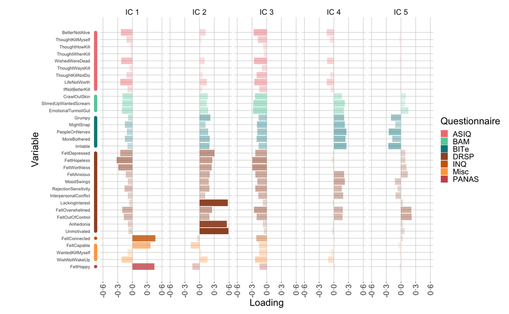

```r
ica_frag <- run_icas(file.path(dat_dir, "dat_reg_fragmented_no-tdia.rds"),
                     ns_comp = c(5, 10, 20),
                     out_path = file.path(dat_dir, "dat_reg_frag_icas.rda"))

fancy_mix_fig(ica_frag[[1]],
              lims = c(-0.6, 0.6),
              ann_x = -0.75,
              save_path = file.path(man_img_dir, "mixing_matrix_5_frag.pdf"))
```

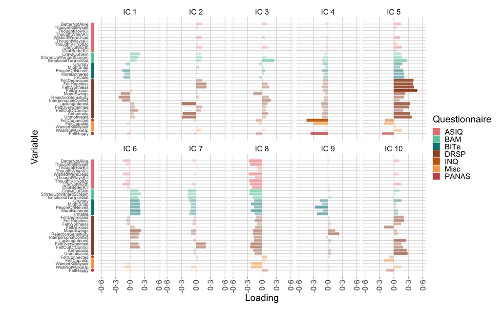

```r
fancy_mix_fig(ica_frag[[2]],
              n_row = 2,
              lims = c(-0.6, 0.6),
              ann_x = -0.78,
              save_path = file.path(man_img_dir, "mixing_matrix_10_frag.pdf"),
              width = 15, height = 15)
```

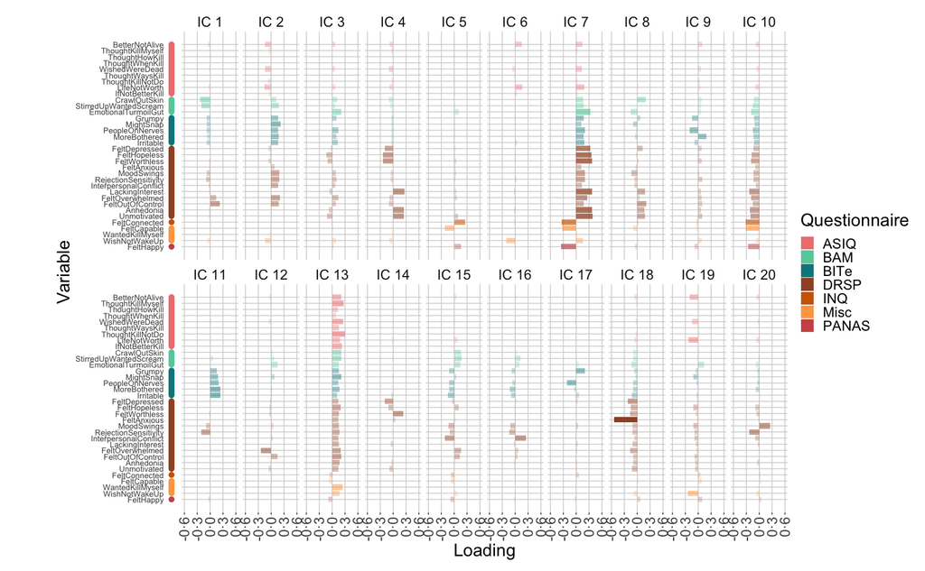

```r
fancy_mix_fig(ica_frag[[3]],
              n_row = 2,
              lims = c(-0.6, 0.6),
              ann_x = -0.9,
              save_path = file.path(man_img_dir, "mixing_matrix_20_frag.pdf"),
              width = 15, height = 15)
```

## Semi-contiguous ICA

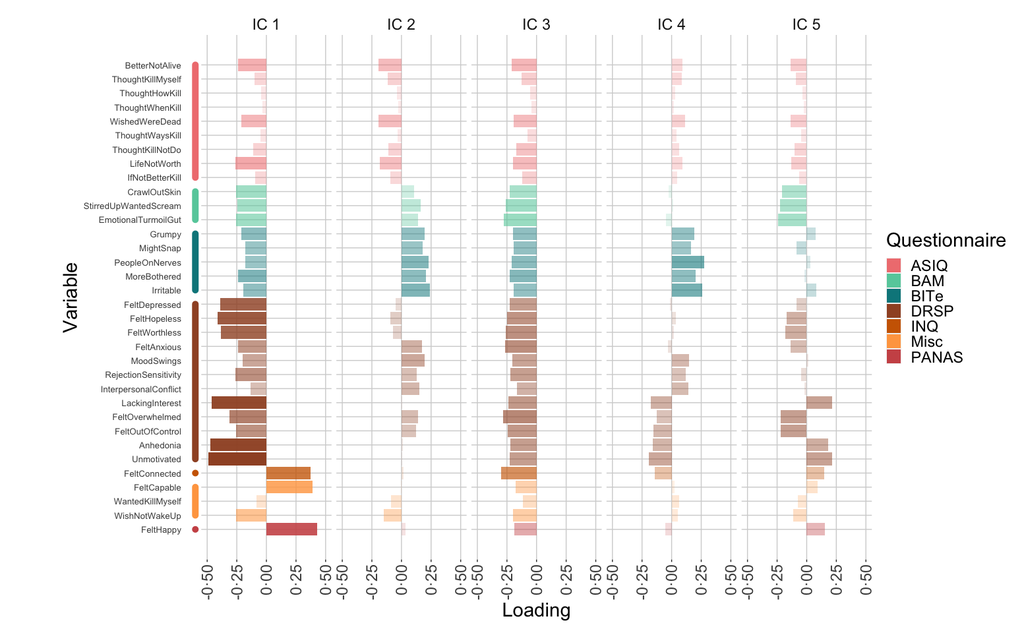

```r
icas <- run_icas(dat_path = file.path(dat_dir, "dat_reg_semi_contiguous_no-tdia.rds"),
                 ns_comp = c(5, 10, 20),
                 out_path = file.path(dat_dir, "dat_reg_contig_icas.rda"))

fancy_mix_fig(icas$`5`,
              save_path = file.path(man_img_dir, "mixing_matrix_5.pdf"))
```

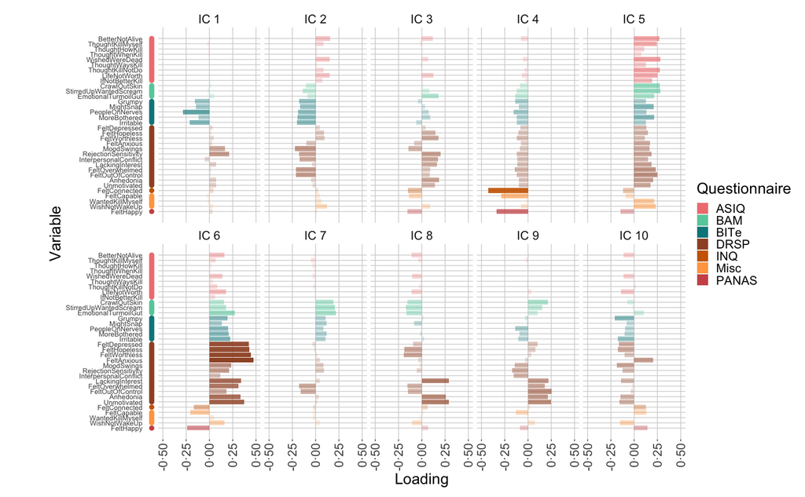

```r
fancy_mix_fig(icas$`10`, n_row = 2,
              save_path = file.path(man_img_dir, "mixing_matrix_10.pdf"),
              width = 15, height = 15)
```

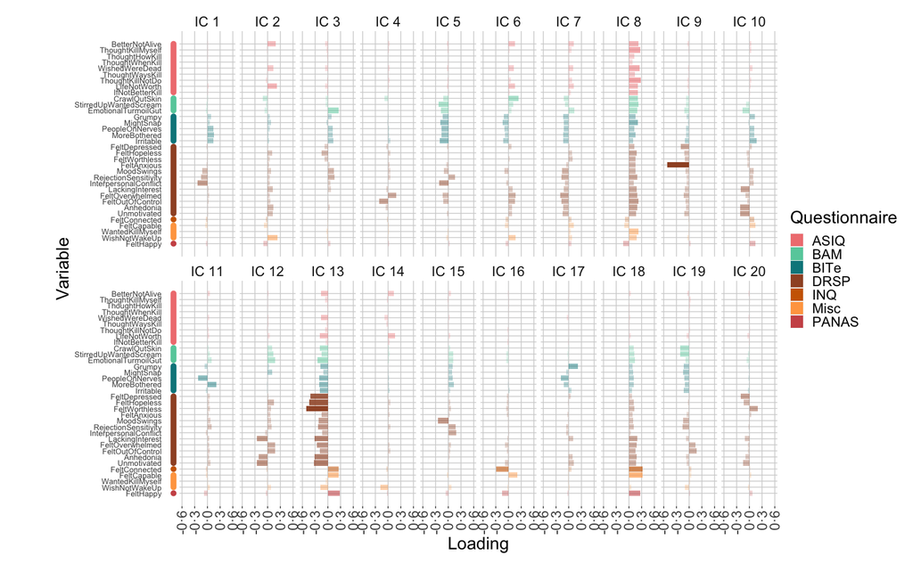

```r
fancy_mix_fig(icas$`20`, n_row = 2, lims = c(-0.6, 0.6),
              save_path = file.path(man_img_dir, "mixing_matrix_20.pdf"),
              width = 15, height = 15)
```

## Within-subject mean-centring

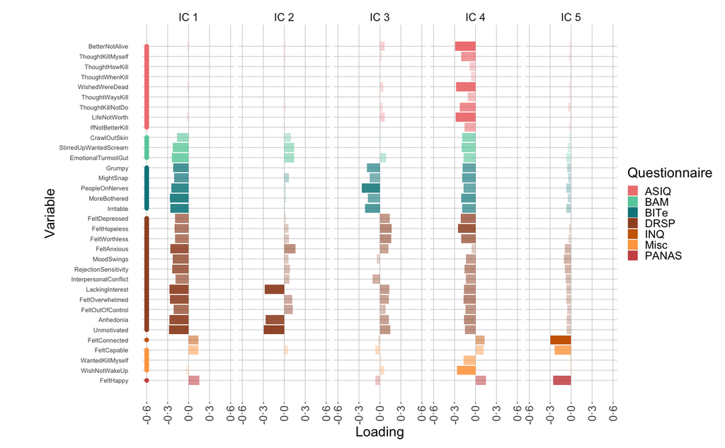

```r
ica_norm <- run_icas(dat_path = file.path(dat_dir, "dat_reg_fragmented_no-tdia.rds"),
                     ns_comp = c(5), sub_norm = TRUE)[[1]]

fancy_mix_fig(ica_norm,
              lims = c(-0.6, 0.6),
              save_path = file.path(man_img_dir, "mixing_matrix_5_norm.pdf"))
```

# Models

This section presents the code and output for running the models. Since validating the model assumptions is a rather space-consuming activity (i.e., lots of plots), it has been delegated to a different file. Take a look at `multilevel_modelling.Rmd` for more information.

```r
source(file.path(src_dir, "lmer.R"))
```

## Fragmented

```r
ls <- prep_reg_dat(
  dat_path = file.path(dat_dir, "dat_reg_fragmented_no-tdia.rds"),
  ica_path = file.path(dat_dir, "dat_reg_frag_icas.rda")
)
```

```
Number of BiAffect cases: 1858
    Number of subjects: 60
Number of self-report cases: 5712
    Number of subjects: 104
Complete-case entries in combined data: 1858
    Number of subjects: 60
Entries in data after filtering out weeks with one observation: 1794
    Number of subjects: 55
```

```r
dat_reg_frag <- ls$dat_reg
dat_bi <- ls$dat_bi
dat_sr <- ls$dat_sr
icas <- ls$icas
subs <- ls$subs
dates <- ls$dates
dats_c_frag <- ls$dats_c
```

### Five components

```r
dat_c1_frag <- dats_c_frag[[1]]

m5.frag.X1.nlme <- lme(X1 ~ medianIKD +
                         percent95IKD +
                         madIKD +
                         autocorrectRate +
                         backspaceRate +
                         totalKeyPresses +
                         active +
                         upright,
                       random = ~ 1 | subject / week,
                       data = dat_c1_frag)

m5.frag.all.nlme <- dat_c1_frag %>%
  summarize(across(starts_with("X", ignore.case = FALSE),
                   ~ list(update(m5.frag.X1.nlme,
                                 reformulate(".", cur_column())))))

estimates_to_csv(file.path(dat_dir, "m5_nlme_p_frag_no-tdia.csv"),
                           m5.frag.all.nlme,
                           include_corrected = TRUE)
```

|  | X1.beta | X1.p' | X1.p | X2.beta | X2.p' | X2.p | X3.beta | X3.p' | X3.p | X4.beta | X4.p' | X4.p | X5.beta | X5.p' | X5.p |
| --- | --- | --- | --- | --- | --- | --- | --- | --- | --- | --- | --- | --- | --- | --- | --- |
| Median IKD | 0.034 | 0.36 | 1 | 0.098 | 0.013 | 0.52 | 0.023 | 0.52 | 1 | -0.094 | 0.030 | 1 | 0.018 | 0.66 | 1 |
| 95th percentile IKD | -0.013 | 0.68 | 1 | -0.030 | 0.36 | 1 | -0.015 | 0.63 | 1 | 0.057 | 0.12 | 1 | -0.023 | 0.51 | 1 |
| MAD IKD | -0.0022 | 0.94 | 1 | -0.027 | 0.42 | 1 | 0.043 | 0.16 | 1 | 0.053 | 0.14 | 1 | 0.0016 | 0.96 | 1 |
| Autocorrect rate | 0.015 | 0.58 | 1 | -0.00029 | 0.99 | 1 | -0.034 | 0.20 | 1 | 0.022 | 0.47 | 1 | -0.015 | 0.62 | 1 |
| Backspace rate | -0.016 | 0.51 | 1 | 0.032 | 0.20 | 1 | 0.018 | 0.45 | 1 | -0.0045 | 0.87 | 1 | 0.0047 | 0.86 | 1 |
| Total number of key presses | -0.00083 | 0.97 | 1 | 0.022 | 0.39 | 1 | -0.030 | 0.21 | 1 | 0.062 | 0.027 | 1 | -0.060 | 0.025 | 1 |
| Movement rate | 0.071 | 0.0051 | 0.20 | -0.12 | 7.6e-06 | 0.00030 | 1.4e-05 | 1 | 1 | 0.055 | 0.058 | 1 | -0.020 | 0.48 | 1 |
| Upright rate | 0.037 | 0.14 | 1 | 0.016 | 0.55 | 1 | 0.026 | 0.29 | 1 | 0.017 | 0.56 | 1 | -0.027 | 0.32 | 1 |

### Ten components

```r
dat_c2_frag <- dats_c_frag[[2]]

m10.frag.X1.nlme <- lme(X1 ~ medianIKD +
                           percent95IKD +
                           madIKD +
                           autocorrectRate +
                           backspaceRate +
                           totalKeyPresses +
                           active +
                           upright,
                         random = ~ 1 | subject / week,
                         data = dat_c2_frag)

m10.frag.all.nlme <- dat_c2_frag %>%
  summarize(across(starts_with("X", ignore.case = FALSE),
                   ~ list(update(m10.frag.X1.nlme,
                                 reformulate(".", cur_column())))))

estimates_to_csv(file.path(dat_dir, "m10_nlme_p_frag_no-tdia.csv"),
                 m10.frag.all.nlme,
                 include_corrected = TRUE,
                 transpose = TRUE)
```

|  | Upright rate | Movement rate | Total number of key presses | Backspace rate | Autocorrect rate | MAD IKD | 95th percentile IKD | Median IKD |
| --- | --- | --- | --- | --- | --- | --- | --- | --- |
| X1.beta | 0.0035 | -0.043 | -0.057 | 0.018 | 0.0075 | -0.00060 | -0.043 | 0.0051 |
| X1.p' | 0.90 | 0.15 | 0.048 | 0.53 | 0.81 | 0.99 | 0.25 | 0.91 |
| X1.p | 1 | 1 | 1 | 1 | 1 | 1 | 1 | 1 |
| X2.beta | -0.062 | 0.045 | -0.0086 | -0.038 | -0.0095 | 0.018 | 0.046 | -0.11 |
| X2.p' | 0.027 | 0.12 | 0.75 | 0.16 | 0.76 | 0.61 | 0.20 | 0.0091 |
| X2.p | 1 | 1 | 1 | 1 | 1 | 1 | 1 | 0.73 |
| X3.beta | -0.0042 | -0.042 | -0.056 | 0.034 | 0.0090 | 0.11 | -0.00049 | -0.10 |
| X3.p' | 0.89 | 0.18 | 0.060 | 0.26 | 0.79 | 0.0076 | 0.99 | 0.029 |
| X3.p | 1 | 1 | 1 | 1 | 1 | 0.61 | 1 | 1 |
| X4.beta | -0.0062 | -0.018 | -0.011 | 0.011 | -0.033 | 0.011 | -0.0049 | 0.012 |

[output cut: 20 more lines]

### Twenty components

```r
dat_c3_frag <- dats_c_frag[[3]]

m20.frag.X1.nlme <- lme(X1 ~ medianIKD +
                           percent95IKD +
                           madIKD +
                           autocorrectRate +
                           backspaceRate +
                           totalKeyPresses +
                           active +
                           upright,
                         random = ~ 1 | subject / week,
                         data = dat_c3_frag)

m20.frag.all.nlme <- dat_c3_frag %>%
  summarize(across(starts_with("X", ignore.case = FALSE),
                   ~ list(update(m20.frag.X1.nlme,
                                 reformulate(".", cur_column())))))

estimates_to_csv(file.path(dat_dir, "m20_nlme_p_frag_no-tdia.csv"),
                 m20.frag.all.nlme,
                 include_corrected = TRUE,
                 transpose = TRUE)
```

|  | Upright rate | Movement rate | Total number of key presses | Backspace rate | Autocorrect rate | MAD IKD | 95th percentile IKD | Median IKD |
| --- | --- | --- | --- | --- | --- | --- | --- | --- |
| X1.beta | -0.075 | 0.015 | -0.032 | 0.028 | -0.062 | -0.042 | 0.035 | 0.062 |
| X1.p' | 0.011 | 0.62 | 0.26 | 0.32 | 0.052 | 0.26 | 0.34 | 0.16 |
| X1.p | 1 | 1 | 1 | 1 | 1 | 1 | 1 | 1 |
| X2.beta | -0.021 | 0.040 | 0.065 | -0.033 | 0.031 | 0.044 | 0.089 | -0.074 |
| X2.p' | 0.47 | 0.18 | 0.024 | 0.25 | 0.33 | 0.24 | 0.018 | 0.10 |
| X2.p | 1 | 1 | 1 | 1 | 1 | 1 | 1 | 1 |
| X3.beta | -0.0012 | 0.064 | 0.018 | 0.049 | -0.057 | 0.027 | -0.047 | -0.036 |
| X3.p' | 0.97 | 0.032 | 0.52 | 0.085 | 0.074 | 0.48 | 0.21 | 0.42 |
| X3.p | 1 | 1 | 1 | 1 | 1 | 1 | 1 | 1 |
| X4.beta | 0.080 | -0.047 | 0.0023 | 0.059 | -0.0086 | -0.0085 | -0.049 | 0.074 |

[output cut: 50 more lines]

## Semi-contiguous

```r
ls <- prep_reg_dat(
  dat_path = file.path(dat_dir, "dat_reg_semi_contiguous_no-tdia.rds"),
  ica_path = file.path(dat_dir, "dat_reg_contig_icas.rda")
)
```

```
Number of BiAffect cases: 1492
    Number of subjects: 53
Number of self-report cases: 4215
    Number of subjects: 98
Complete-case entries in combined data: 1492
    Number of subjects: 53
Entries in data after filtering out weeks with one observation: 1454
    Number of subjects: 47
```

```r
dat_reg_contig <- ls$dat_reg
dat_bi <- ls$dat_bi
dat_sr <- ls$dat_sr
```

[output not shown]

```r
icas <- ls$icas
subs <- ls$subs
dates <- ls$dates
dats_c <- ls$dats_c
```

### Five components

```r
dat_c1 <- dats_c[[1]]

m5.X1.nlme <- lme(X1 ~ medianIKD +
                   percent95IKD +
                   madIKD +
                   autocorrectRate +
                   backspaceRate +
                   totalKeyPresses +
                   active +
                   upright,
                 random = ~ 1 | subject / week,
                 data = dat_c1)

m5.all.nlme <- dat_c1 %>%
  summarize(across(starts_with("X", ignore.case = FALSE),
                   ~ list(update(m5.X1.nlme, reformulate(".", cur_column())))))

estimates_to_csv(file.path(dat_dir, "m5_nlme_p_no-tdia.csv"),
                 m5.all.nlme,
                 include_corrected = TRUE)
```

|  | X1.beta | X1.p' | X1.p | X2.beta | X2.p' | X2.p | X3.beta | X3.p' | X3.p | X4.beta | X4.p' | X4.p | X5.beta | X5.p' | X5.p |
| --- | --- | --- | --- | --- | --- | --- | --- | --- | --- | --- | --- | --- | --- | --- | --- |
| Median IKD | -0.044 | 0.25 | 1 | -0.088 | 0.055 | 1 | -0.023 | 0.54 | 1 | -0.084 | 0.062 | 1 | 0.084 | 0.065 | 1 |
| 95th percentile IKD | -0.016 | 0.62 | 1 | 0.033 | 0.38 | 1 | -0.029 | 0.36 | 1 | 0.030 | 0.43 | 1 | -0.039 | 0.31 | 1 |
| MAD IKD | 0.031 | 0.35 | 1 | 0.052 | 0.18 | 1 | 0.032 | 0.33 | 1 | 0.037 | 0.32 | 1 | -0.015 | 0.69 | 1 |
| Autocorrect rate | -0.00062 | 0.98 | 1 | -0.0041 | 0.90 | 1 | -0.051 | 0.071 | 1 | 0.010 | 0.75 | 1 | 0.0019 | 0.95 | 1 |
| Backspace rate | -0.030 | 0.24 | 1 | -0.0037 | 0.90 | 1 | -0.012 | 0.64 | 1 | -0.023 | 0.43 | 1 | 0.051 | 0.086 | 1 |
| Total number of key presses | -0.015 | 0.55 | 1 | 0.046 | 0.13 | 1 | -0.043 | 0.086 | 1 | 0.053 | 0.075 | 1 | 0.0085 | 0.78 | 1 |
| Movement rate | 0.12 | 4.8e-06 | 0.00019 | 0.039 | 0.21 | 1 | -0.011 | 0.66 | 1 | 0.035 | 0.25 | 1 | -0.0071 | 0.82 | 1 |
| Upright rate | 0.048 | 0.068 | 1 | 0.025 | 0.43 | 1 | -0.0083 | 0.75 | 1 | -0.0077 | 0.80 | 1 | 0.033 | 0.29 | 1 |

### Ten components

```r
dat_c2 <- dats_c[[2]]

m10.X1.nlme <- lme(X1 ~ medianIKD +
                     percent95IKD +
                     madIKD +
                     autocorrectRate +
                     backspaceRate +
                     totalKeyPresses +
                     active +
                     upright,
                   random = ~ 1 | subject / week,
                   data = dat_c2)

m10.all.nlme <- dat_c2 %>%
  summarize(across(starts_with("X", ignore.case = FALSE),
                   ~ list(update(m10.X1.nlme, reformulate(".", cur_column())))))

estimates_to_csv(file.path(dat_dir, "m10_nlme_p_no-tdia.csv"),
                 m10.all.nlme,
                 include_corrected = TRUE)
```

|  | X1.beta | X1.p' | X1.p | X2.beta | X2.p' | X2.p | X3.beta | X3.p' | X3.p | X4.beta | X4.p' | X4.p | X5.beta | X5.p' | X5.p | X6.beta | X6.p' | X6.p | X7.beta | X7.p' | X7.p | X8.beta | X8.p' | X8.p | X9.beta | X9.p' | X9.p | X10.beta | X10.p' | … |
| --- | --- | --- | --- | --- | --- | --- | --- | --- | --- | --- | --- | --- | --- | --- | --- | --- | --- | --- | --- | --- | --- | --- | --- | --- | --- | --- | --- | --- | --- | --- |
| Median IKD | 0.054 | 0.29 | 1 | 0.067 | 0.16 | 1 | -0.087 | 0.080 | 1 | 0.026 | 0.51 | 1 | 0.066 | 0.15 | 1 | 0.048 | 0.25 | 1 | -0.065 | 0.17 | 1 | 0.13 | 0.0057 | 0.46 | 0.061 | 0.18 | 1 | -0.0040 | 0.93 | … |
| 95th percentile IKD | -0.022 | 0.60 | 1 | -0.048 | 0.23 | 1 | 0.026 | 0.54 | 1 | -0.024 | 0.48 | 1 | 0.014 | 0.73 | 1 | 0.020 | 0.56 | 1 | -0.053 | 0.19 | 1 | -0.046 | 0.24 | 1 | -0.021 | 0.58 | 1 | -0.012 | 0.76 | … |
| MAD IKD | -0.020 | 0.65 | 1 | -0.044 | 0.27 | 1 | 0.070 | 0.10 | 1 | 0.00092 | 0.98 | 1 | -0.028 | 0.48 | 1 | -0.047 | 0.18 | 1 | 0.043 | 0.29 | 1 | -0.028 | 0.48 | 1 | -0.049 | 0.20 | 1 | 0.018 | 0.64 | … |
| Autocorrect rate | -0.015 | 0.69 | 1 | 0.026 | 0.45 | 1 | 0.0042 | 0.91 | 1 | -0.036 | 0.22 | 1 | 0.035 | 0.30 | 1 | 0.020 | 0.53 | 1 | 0.036 | 0.31 | 1 | 0.013 | 0.72 | 1 | -0.010 | 0.76 | 1 | 0.038 | 0.27 | … |
| Backspace rate | 0.0026 | 0.94 | 1 | 0.0026 | 0.93 | 1 | 0.018 | 0.58 | 1 | -0.0059 | 0.82 | 1 | 0.0061 | 0.84 | 1 | 0.030 | 0.27 | 1 | -0.012 | 0.69 | 1 | 0.064 | 0.037 | 1 | 0.0048 | 0.87 | 1 | 0.016 | 0.61 | … |
| Total number of key presses | -0.0051 | 0.88 | 1 | -0.051 | 0.10 | 1 | -0.052 | 0.11 | 1 | -0.012 | 0.65 | 1 | 0.069 | 0.021 | 1 | 0.014 | 0.60 | 1 | 0.013 | 0.69 | 1 | 0.021 | 0.49 | 1 | -0.038 | 0.21 | 1 | -0.0096 | 0.75 | … |
| Movement rate | -0.023 | 0.50 | 1 | -0.036 | 0.25 | 1 | -0.056 | 0.097 | 1 | -0.037 | 0.16 | 1 | -0.026 | 0.40 | 1 | -0.057 | 0.044 | 1 | -0.047 | 0.15 | 1 | -0.024 | 0.44 | 1 | -0.077 | 0.012 | 0.96 | 0.046 | 0.14 | … |
| Upright rate | 0.0010 | 0.98 | 1 | 0.014 | 0.66 | 1 | -0.021 | 0.53 | 1 | -0.028 | 0.30 | 1 | -0.038 | 0.22 | 1 | -0.013 | 0.64 | 1 | 0.082 | 0.012 | 0.96 | 0.028 | 0.38 | 1 | -0.013 | 0.67 | 1 | 0.048 | 0.13 | … |

### Twenty components

```r
dat_c3 <- dats_c[[3]]

m20.X1.nlme <- lme(X1 ~ medianIKD +
                     percent95IKD +
                     madIKD +
                     autocorrectRate +
                     backspaceRate +
                     totalKeyPresses +
                     active +
                     upright,
                   random = ~ 1 | subject / week,
                   data = dat_c3)

m20.all.nlme <- dat_c3 %>%
  summarize(across(starts_with("X", ignore.case = FALSE),
                   ~ list(update(m20.X1.nlme, reformulate(".", cur_column())))))

estimates_to_csv(file.path(dat_dir, "m20_nlme_p_no-tdia.csv"),
                 m20.all.nlme,
                 include_corrected = TRUE)
```

|  | X1.beta | X1.p' | X1.p | X2.beta | X2.p' | X2.p | X3.beta | X3.p' | X3.p | X4.beta | X4.p' | X4.p | X5.beta | X5.p' | X5.p | X6.beta | X6.p' | X6.p | X7.beta | X7.p' | X7.p | X8.beta | X8.p' | X8.p | X9.beta | X9.p' | X9.p | X10.beta | X10.p' | … |
| --- | --- | --- | --- | --- | --- | --- | --- | --- | --- | --- | --- | --- | --- | --- | --- | --- | --- | --- | --- | --- | --- | --- | --- | --- | --- | --- | --- | --- | --- | --- |
| Median IKD | 0.050 | 0.35 | 1 | 0.016 | 0.74 | 1 | 0.036 | 0.46 | 1 | -0.024 | 0.63 | 1 | 0.14 | 0.0093 | 1 | 0.068 | 0.16 | 1 | -0.021 | 0.65 | 1 | 0.095 | 0.038 | 1 | -0.092 | 0.057 | 1 | 0.0058 | 0.91 | … |
| 95th percentile IKD | -0.015 | 0.74 | 1 | 0.0097 | 0.81 | 1 | -0.036 | 0.38 | 1 | -0.012 | 0.78 | 1 | -0.011 | 0.80 | 1 | -0.069 | 0.090 | 1 | -0.042 | 0.27 | 1 | 0.036 | 0.36 | 1 | 0.024 | 0.56 | 1 | 0.00019 | 1 | … |
| MAD IKD | -0.068 | 0.14 | 1 | -0.039 | 0.34 | 1 | 0.00083 | 0.98 | 1 | -0.015 | 0.72 | 1 | -0.083 | 0.062 | 1 | -0.014 | 0.74 | 1 | 0.0063 | 0.87 | 1 | -0.061 | 0.12 | 1 | 0.042 | 0.31 | 1 | 0.017 | 0.67 | … |
| Autocorrect rate | -0.037 | 0.33 | 1 | -0.056 | 0.11 | 1 | -0.077 | 0.033 | 1 | -0.034 | 0.34 | 1 | -0.033 | 0.38 | 1 | -0.0099 | 0.78 | 1 | 0.018 | 0.59 | 1 | 0.027 | 0.41 | 1 | -0.027 | 0.45 | 1 | 0.0084 | 0.81 | … |
| Backspace rate | 0.017 | 0.62 | 1 | 0.081 | 0.0095 | 1 | 0.053 | 0.097 | 1 | 0.030 | 0.36 | 1 | 0.022 | 0.51 | 1 | 0.036 | 0.26 | 1 | -0.020 | 0.51 | 1 | -0.013 | 0.66 | 1 | -0.048 | 0.13 | 1 | -0.026 | 0.41 | … |
| Total number of key presses | -0.035 | 0.31 | 1 | -0.012 | 0.70 | 1 | 0.022 | 0.49 | 1 | 0.0087 | 0.79 | 1 | -0.048 | 0.16 | 1 | -0.034 | 0.28 | 1 | -0.042 | 0.16 | 1 | 0.075 | 0.012 | 1 | -0.018 | 0.56 | 1 | 0.031 | 0.34 | … |
| Movement rate | 0.0016 | 0.96 | 1 | 0.0027 | 0.93 | 1 | 0.016 | 0.62 | 1 | -0.0062 | 0.85 | 1 | 0.018 | 0.61 | 1 | 0.012 | 0.71 | 1 | -0.036 | 0.24 | 1 | -0.049 | 0.11 | 1 | -0.062 | 0.056 | 1 | 0.11 | 0.00066 | … |
| Upright rate | -0.014 | 0.69 | 1 | -0.011 | 0.74 | 1 | 0.024 | 0.47 | 1 | 0.0029 | 0.93 | 1 | 0.0085 | 0.81 | 1 | -0.0088 | 0.79 | 1 | 0.025 | 0.41 | 1 | -0.033 | 0.29 | 1 | -0.0074 | 0.82 | 1 | -0.054 | 0.10 | … |